# Bayesian Learning - Assignment 3

Antonio Miranda Escalada

Manuel Rodríguez Ramírez

Sergio Arias Pedraza

March 30, 2019

# 0. Required packages

# 1. Introduction

The aim of this project is to analyse a multidimensional dataset which mainly needs to count with enough observations, a considerable number of quantitative variables and, at least, one qualitative variable in order to divide the data into different groups of interest. Considering that the dataset must fulfill all the previous characteristics, “FIFA 18 Player Dataset](https://www.kaggle.com/kevinmh/fifa-18-more-complete-player-dataset#complete.csv)” (17995 objects x 185 columns) has been chosen. The mentioned file contains information about the players who take part in the classical football video game. Between the different fields of the dataset, there are some qualitative variables which are candidates to split it in different groups, such as nationality, league or position of the player. In addition, each player shows their qualities in a detailed way. For example, these qualities can be physical (sprint speed, jumping.), technical (shot power, finishing.) or tactical (positioning, vision.). They are valued with a numeric value between 0 and 100. To conclude, after a first study about the data, a cleaning is necessary so that remove some information that it is not useful in this project. Therefore, in the following steps of this project, this action and the proper analysis will be performed.

# 2. Dataset preparation

As it was exposed in the introduction of this project, the amount of available data was huge in order to handle them. Therefore, in this new section, the first goal is to reduce the quantity of variables whereas the main information is conserved. In the original dataset, the wide quantity of variables makes strongly complicated to extract conclusions. For this reason, a lot of variables have been cleaned in different steps. On the one hand, the video game counts with different abilities which have a Boolean value depending on if a single player has it or not. For instance, some of these skills are technical dribbler trait, tackling speciality or play marker speciality, and they are given to players which are actual specialist in that branches. Nevertheless, they are related to numeric variables, so they are redundant, reason why they have been deleted. Secondly, other repeated information is provided about the player position. This video game, as it happens in the real world, takes into account many sub positions between the main ones. For example, midfielder position has inside a variety of them (centre attacking midfielder, right defence midfielder…), and the same with strikers and defenders. In order to have only four different classes, every single position have been grouped by the main four: goalkeeper, defender, midfielder and striker. In addition, some players have the capacity to assume different roles and they can play, for example, either midfielder or striker. In these cases, and analogously with defenders and midfielders, it has been chosen the most valued position for each player.

```
##  [1] "id"           "name"         "club"         "age"
##  [5] "league"       "nationality"  "height_cm"    "weight_kg"
##  [9] "pace"         "shooting"     "passing"      "dribbling"
## [13] "defense"      "physical"     "gk_abilities" "position"
```

```
##   id              name                club age                    league
## 1  1 Cristiano Ronaldo      Real Madrid CF  32 Spanish Primera DivisiÌ_n
## 2  2          L. Messi        FC Barcelona  30 Spanish Primera DivisiÌ_n
## 3  3            Neymar Paris Saint-Germain  25            French Ligue 1
## 4  4        L. SuÌÁrez        FC Barcelona  30 Spanish Primera DivisiÌ_n
## 5  5          M. Neuer    FC Bayern Munich  31         German Bundesliga
## 6  6    R. Lewandowski    FC Bayern Munich  28         German Bundesliga
##   nationality height_cm weight_kg pace shooting passing dribbling defense
## 1    Portugal       185        80   90       93      82        90      33
## 2   Argentina       170        72   89       90      86        96      26
## 3      Brazil       175        68   92       84      79        95      30
## 4     Uruguay       182        86   82       90      79        87      42
## 5     Germany       193        92   91       90      95        89      60
## 6      Poland       185        79   81       88      75        86      38
##   physical gk_abilities   position
## 1       80           12    Striker
## 2       61           11    Striker
## 3       60           12    Striker
## 4       81           31    Striker
## 5       91           91 Goalkeeper
## 6       82           10    Striker
```

```
##  [1] "height_cm"    "weight_kg"    "pace"         "shooting"
##  [5] "passing"      "dribbling"    "defense"      "physical"
##  [9] "gk_abilities" "position"
```

```
##   height_cm weight_kg pace shooting passing dribbling defense physical
## 1       185        80   90       93      82        90      33       80
## 2       170        72   89       90      86        96      26       61
## 3       175        68   92       84      79        95      30       60
## 4       182        86   82       90      79        87      42       81
## 5       193        92   91       90      95        89      60       91
## 6       185        79   81       88      75        86      38       82
##   gk_abilities   position
## 1           12    Striker
## 2           11    Striker
## 3           12    Striker
## 4           31    Striker
## 5           91 Goalkeeper
## 6           10    Striker
```

Finally, although video game considers many quantitative characteristics for each player, they can be grouped by seven principal skills: pace (acceleration, sprint speed), shooting (positioning, finishing, shot power, long shot, volleys, penalties), dribbling (agility, balance, reactions, ball control, dribbling), defending (interceptions, heading accuracy, marking, standing tackle, sliding tackle), passing (vision, crossing, free kick accuracy, short passing, curve), physicality (jumping, stamina, strength, aggression) and goalkeeper abilities. To conclude this cleaning, the final fields are the following list: * Height (cm) * Weight (kg) * Pace (0 - 100) * Shooting (0 - 100) * Passing (0 - 100) * Dribbling (0 - 100) * Defending (0 - 100) * Physicality (0 - 100) * Goalkeeper abilities (0 - 100) * Position (goalkeeper, defender, midfielder, striker) Nevertheless, although the descriptive analysis is performed with these variables, the rest of them are stored in the case that they are useful in the future, as well other qualitative ones.

# 3. Descriptive Analysis

### 3.1. Position

In this case, as a qualitative variable, it is interesting to know the class frequency for each position in order to know if the distribution of them is coherent with the usual number of them in the team. Therefore, as it can be observed in the first figures, a 36.6% of players are defenders, a 25.5% are midfielders, a 26.6% are strikers and a 11.2% are goalkeepers. This fit with typical tactics in the teams, such as 4-3-3, and the squad compositions with, in general, 3 goalkeepers, 10 defenders, 7 midfielders and 7 strikers. Obviously, each team has a particular situation and this number could change. In addition, it has to be taken into account that there are 253 players who do not play in any team, but with their national team. Notice that this fact is translated into an unbalanced datset.

```r
fifa.x <- fifa [, 1:ncol(fifa)-1]
fifa.y <- fifa [, ncol(fifa)]

fifa.y.abs.freq <- table(fifa.y)[c("Goalkeeper", "Defender", "Midfielder", "Striker")]
fifa.y.abs.freq
```

```
## fifa.y
## Goalkeeper   Defender Midfielder    Striker
##       2021       6592       4590       4791
```

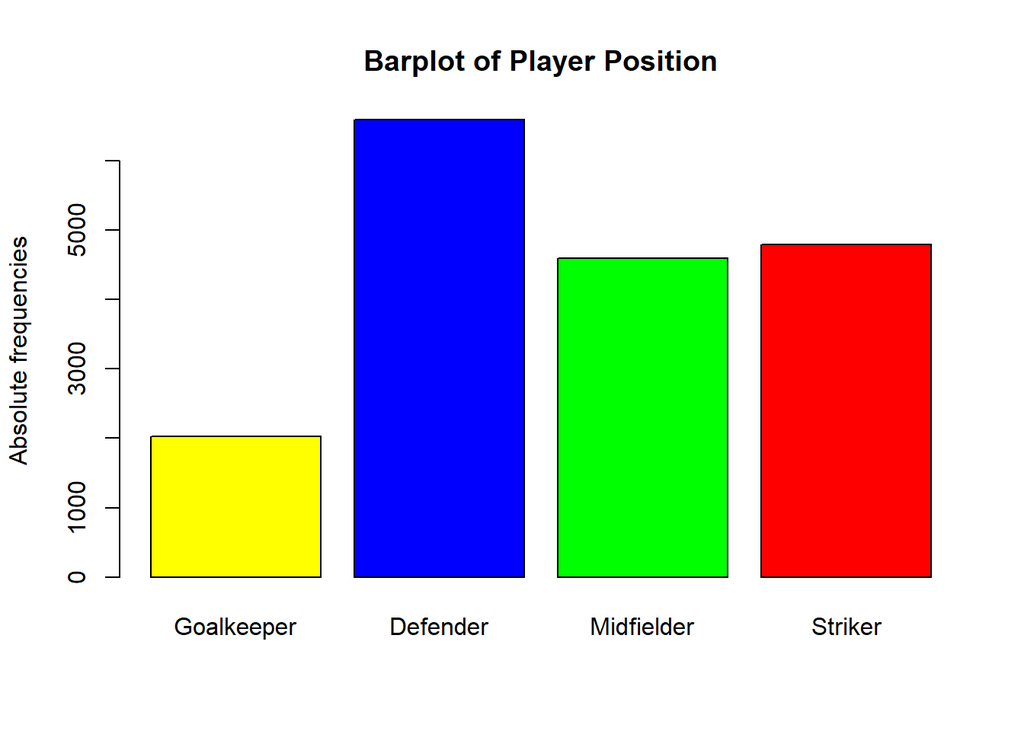

```r
barplot(fifa.y.abs.freq, col=c("yellow", "blue", "green", "red"), main="Barplot of Player Position", ylab="Absolute frequencies")
```

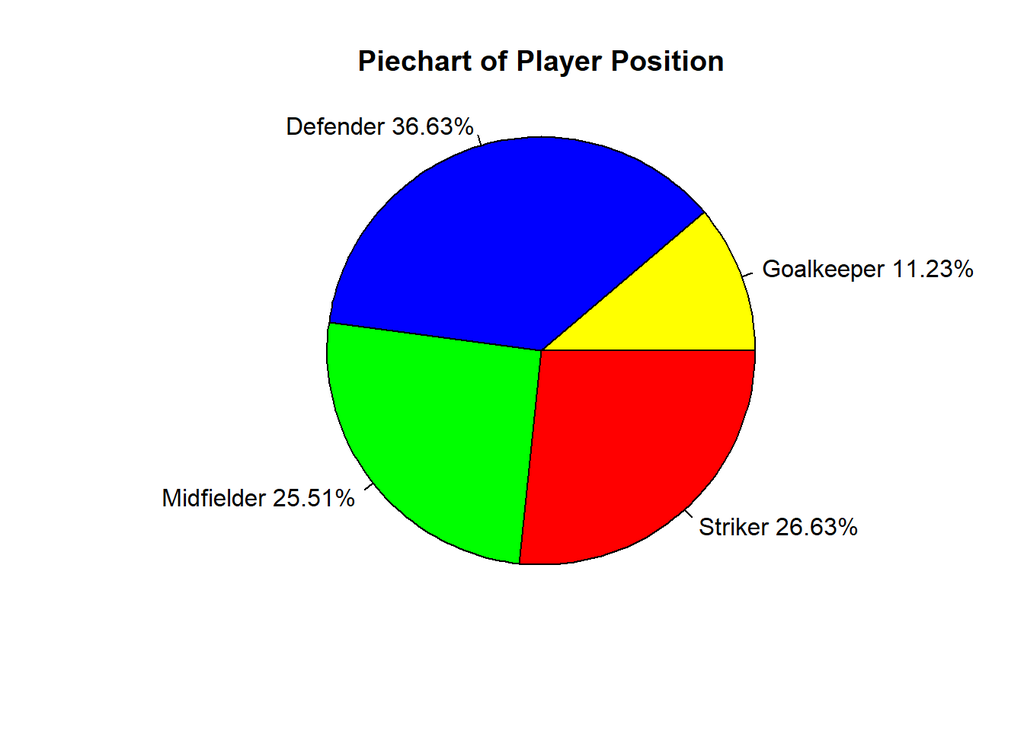

```r
fifa.y.rel.freq <- round(fifa.y.abs.freq/sum(fifa.y.abs.freq)*100, 2)
labels <- paste(c("Goalkeeper", "Defender", "Midfielder", "Striker"), fifa.y.rel.freq)
labels <- paste(labels, "%", sep="")
pie(fifa.y.abs.freq, col=c("yellow", "blue", "green", "red"), main="Piechart of Player Position", radius=1, labels=labels)
```

### 3.2. Quantitative variables

In this sub section, a wide variety of visualizations have been produced with the intention of having a clear idea about the distribution of the abilities among the different positions. First of all, the boxplots allow us to observe some characteristics about data location and spread divided by position and ability, including height and weight. It means that some interesting conclusions are shown.

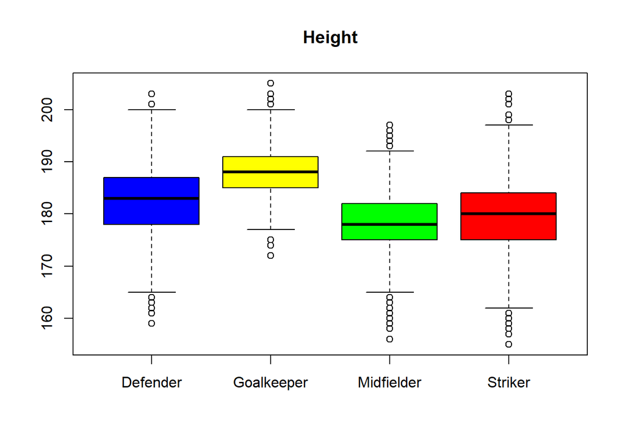

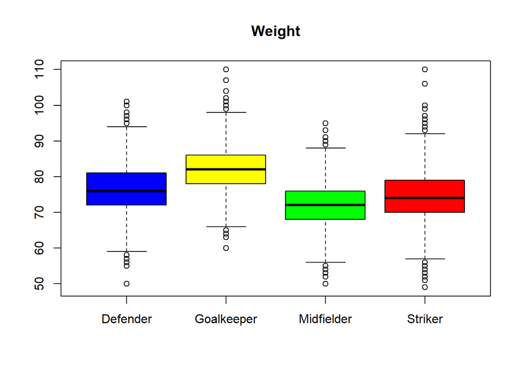

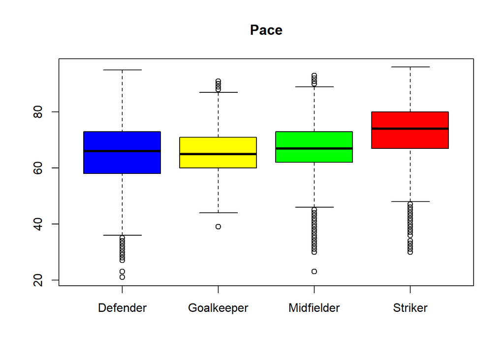

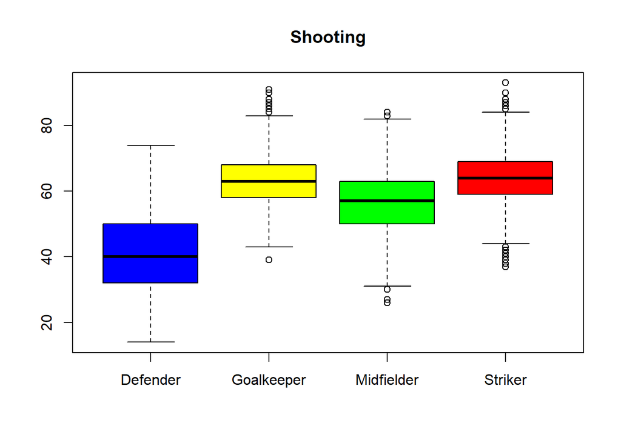

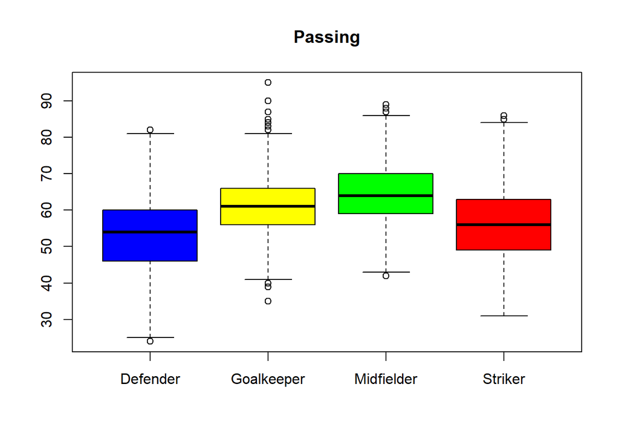

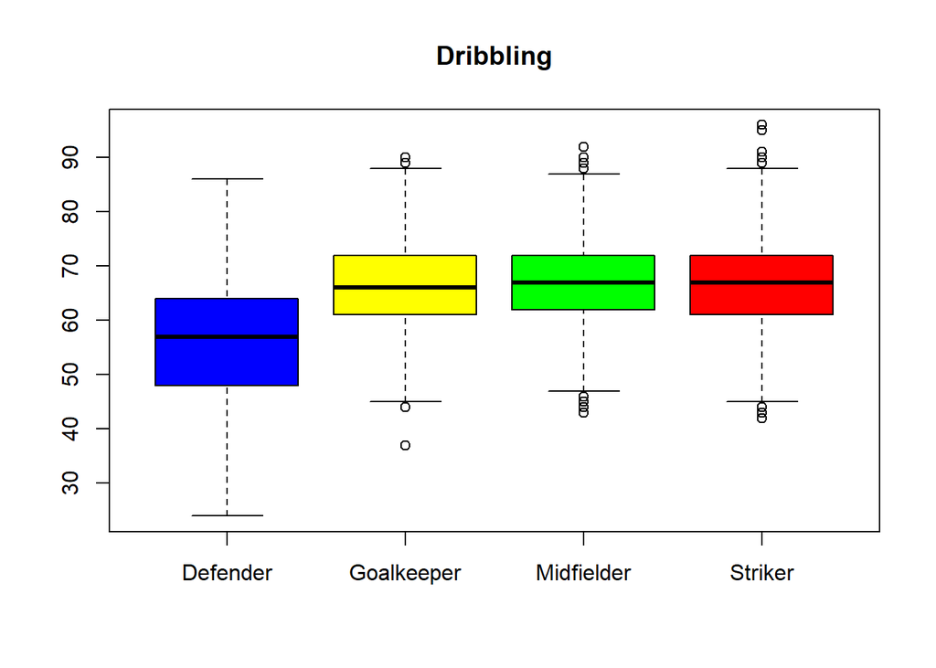

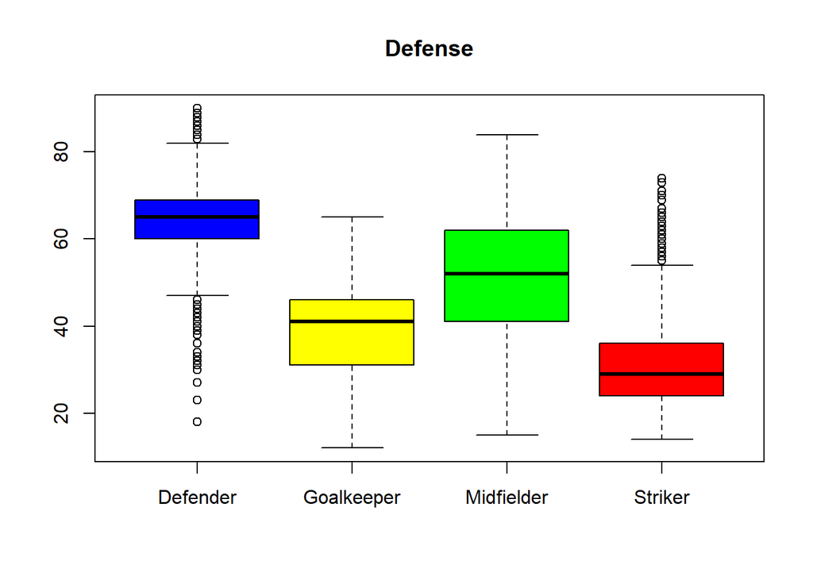

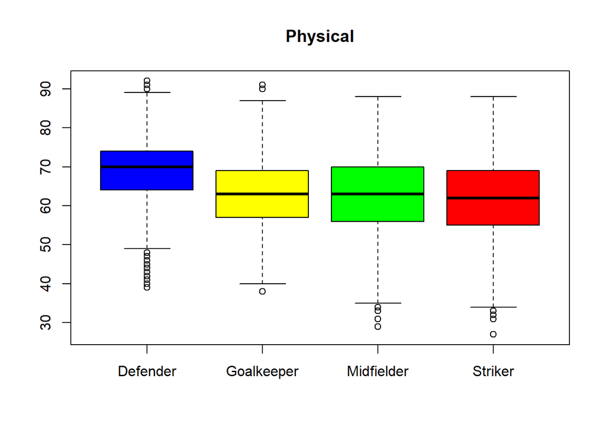

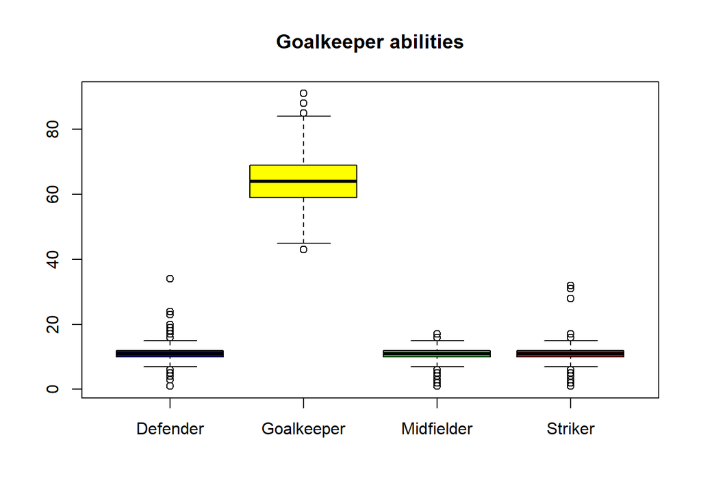

```r
fifa.y.qualities <- c("Height", "Weight", "Pace", "Shooting", "Passing", "Dribbling", "Defense", "Physical", "Goalkeeper abilities")

for(i in seq(1,length(fifa.y.qualities), by=1)){
  boxplot(fifa.x[,i]~fifa.y, main=fifa.y.qualities[i], xlab="", col=c("blue", "yellow", "green", "red"))
}
```

On the one hand, goalkeepers highlight, obviously, because of their goalkeeper abilities, their height and their weight. All of these characteristics, together with an acceptable passing skill, have sense if the current tendency about this position is taken into account, where the physic of the goalkeeper is relevant, and they have importance in the game as a field player. In fact, they are at the same level of midfielders and strikers in dribbling skills, which shows that they are not only to avoid goals. Secondly, considering defender tasks, it seems logic that they have the defence skill higher than the rest of the positions. Nevertheless, their physical power is important too, as it can be seen. In addition, players who participate in this position do not need to score goals, so in skills such as dribbling and shooting they have, in general, the lowest values. In the midfielders’ case, they have the mission of creating and being the pillar of their teams, which is traduced in good passing skills. Furthermore, they are complete players who are not the best in other qualities, but they have acceptable values. A curiosity is that they have, in average, the lowest height and weight. This is probably provoked by the typical characteristics of offensive midfielders, who usually are small whereas they are talented. Finally, strikers are prepared to score goals, which explains their shooting, pace and dribbling skills while, in average, they are the worst in defence tasks. It is curious that, goalkeepers have a similar ability of shooting. However, the use of it is different because, while strikers use it in order to achieve goals, in goalkeepers is used to start the game from their area with a long passing.

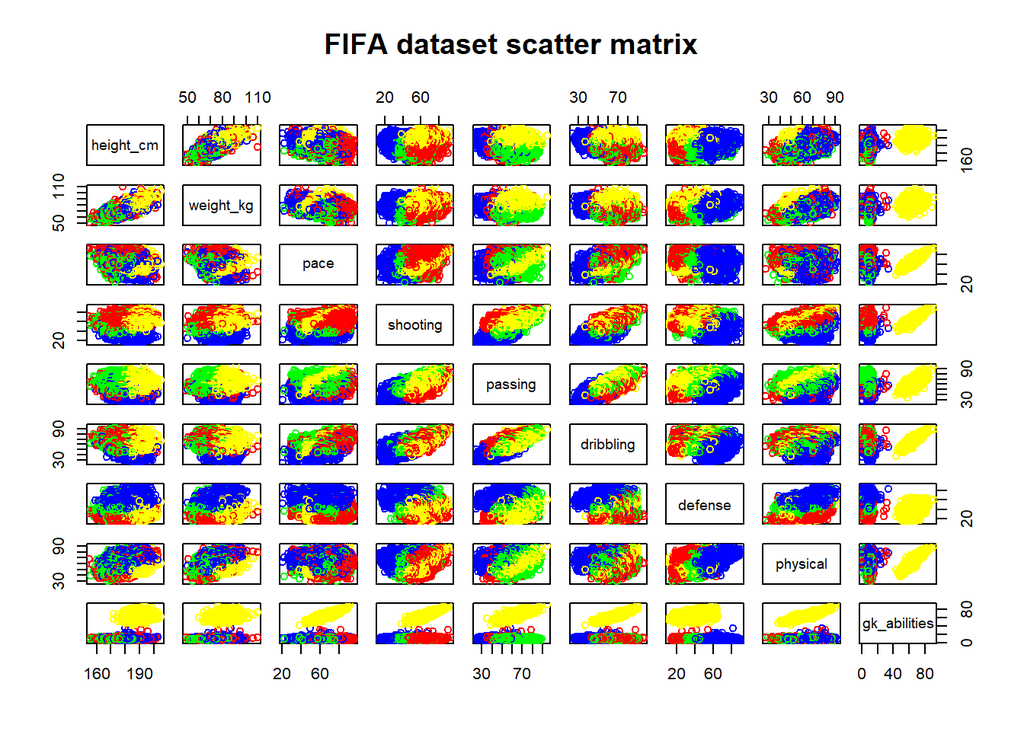

```r
fifa.x.colour <- seq(1, 17994)
fifa.x.colour[fifa.y=="Goalkeeper"] <- "yellow"
fifa.x.colour[fifa.y=="Defender"] <- "blue"
fifa.x.colour[fifa.y=="Midfielder"] <- "green"
fifa.x.colour[fifa.y=="Striker"] <- "red"

pairs(fifa.x, col=c("blue", "yellow", "green", "red")[fifa.y],  main="FIFA dataset scatter matrix")
```

As it can be observed in the previous scatter matrix about the dat, it is really complicated to extract conclusions from the graph taking into account the raw information, with this quantity of variables. Nevertheless, some groups are identified depending on the variables, what is expected because each position has its particularities. With the aim of knowing the adequacy of the following classification methods, it is interesting to have information about the data distribution. Therefore, density functions have been computed for each quantitative variable and, although in general they have acceptable behaviours, shooting, defence and goalkeeper abilities are not as gaussian as they should.

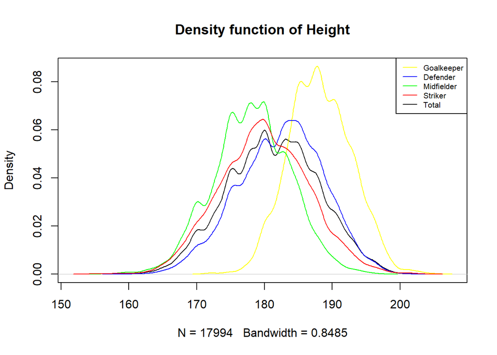

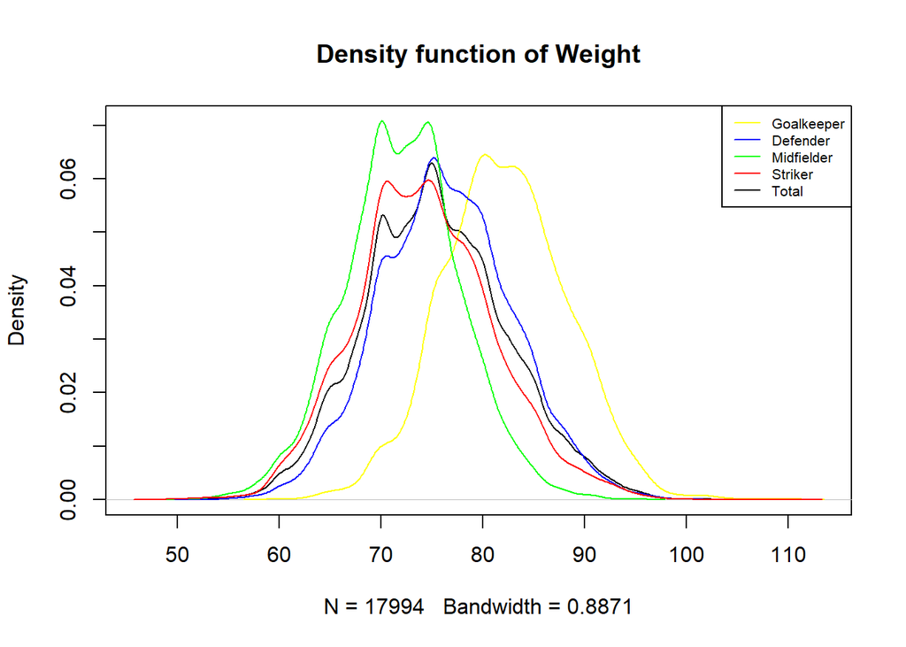

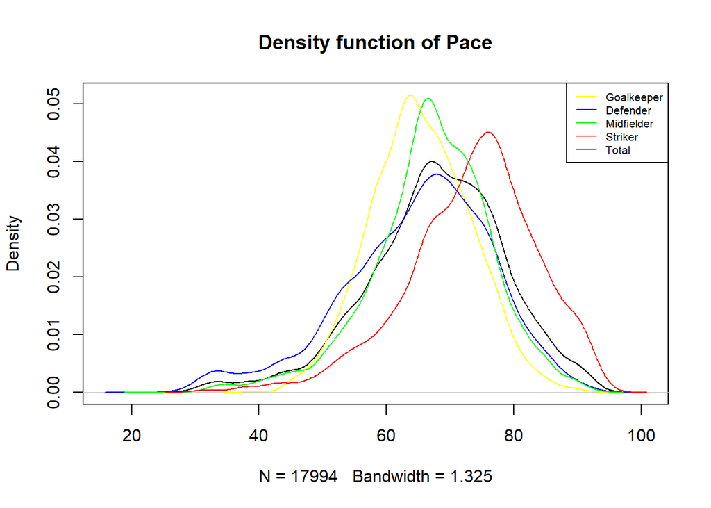

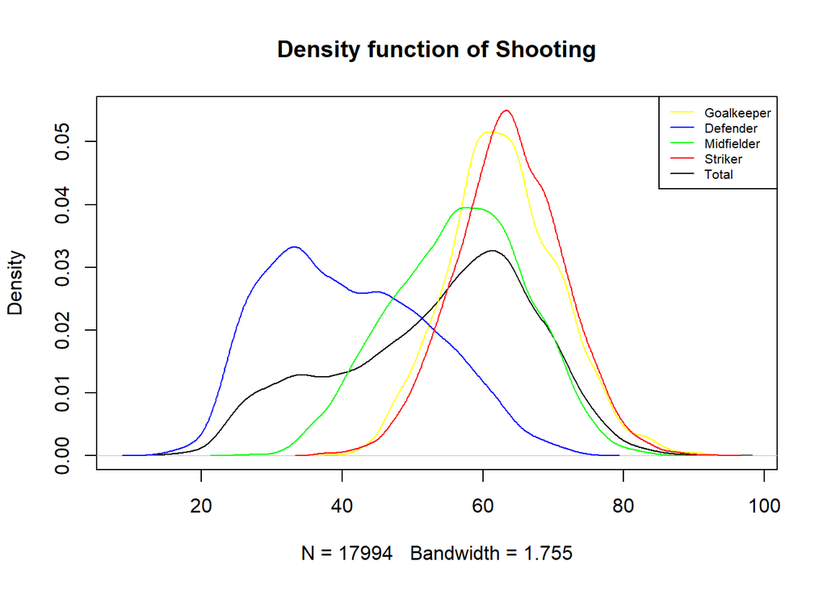

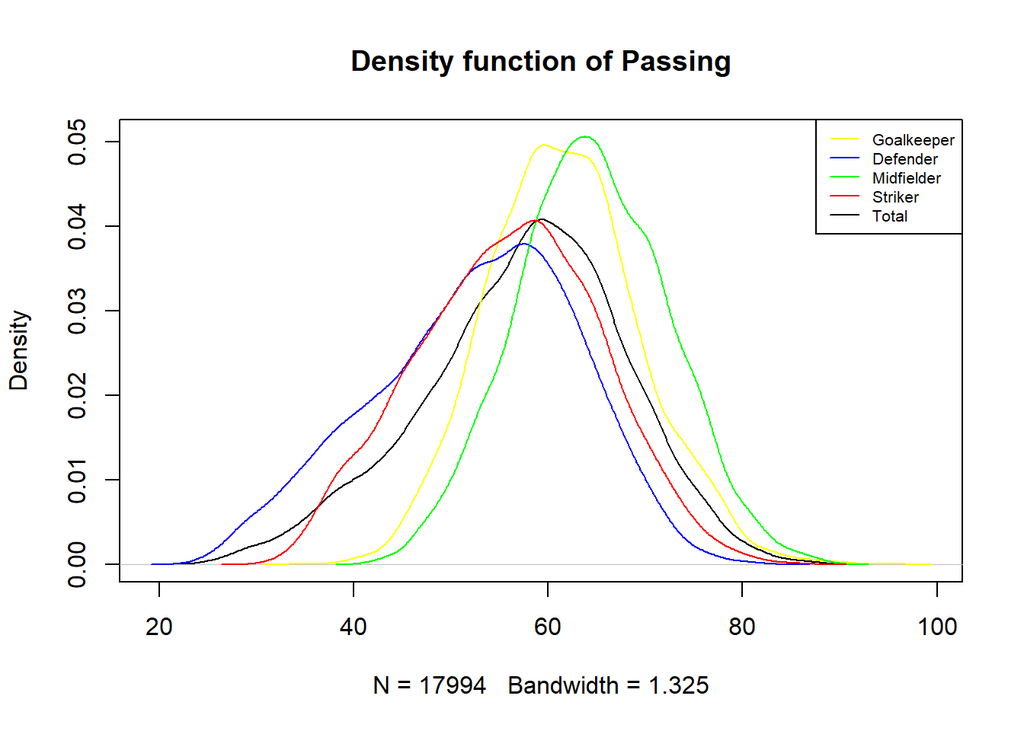

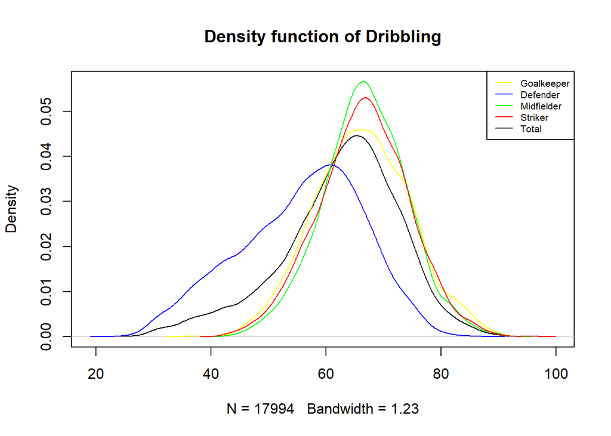

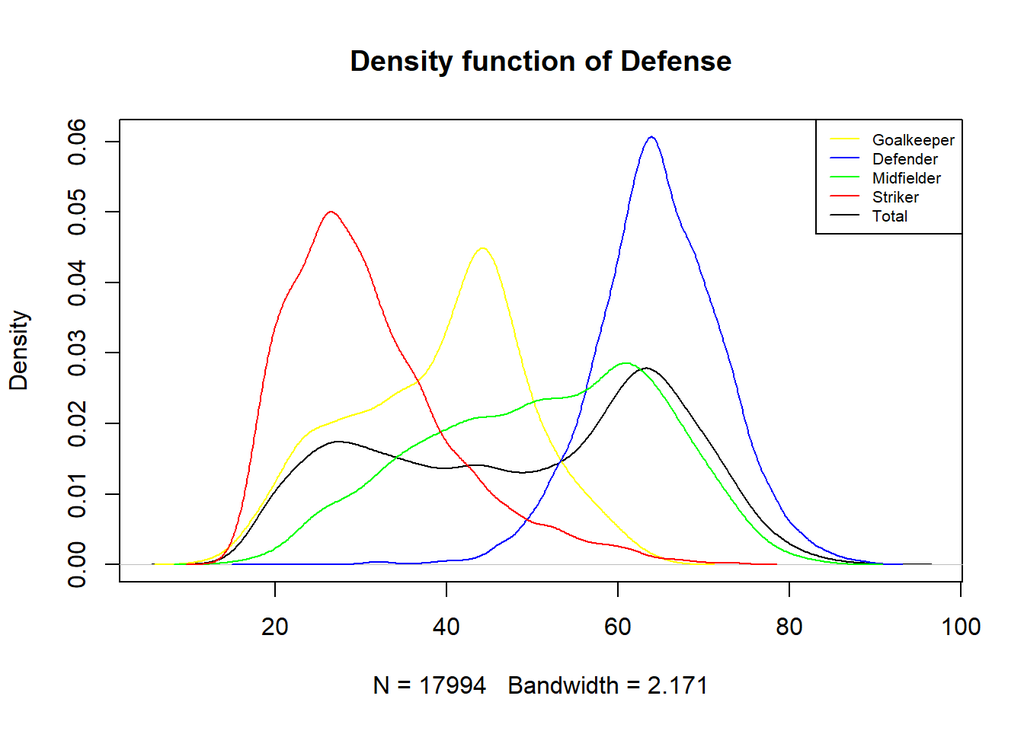

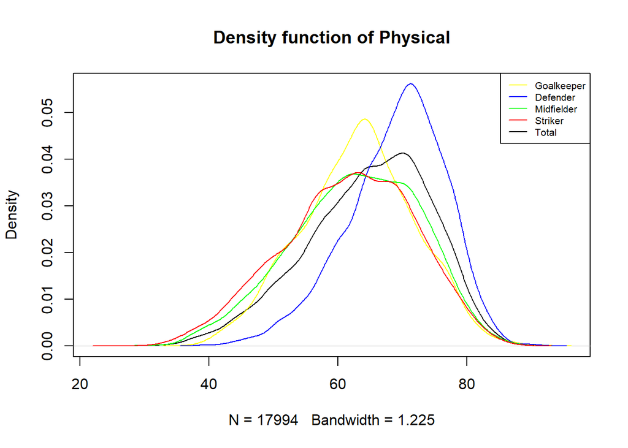

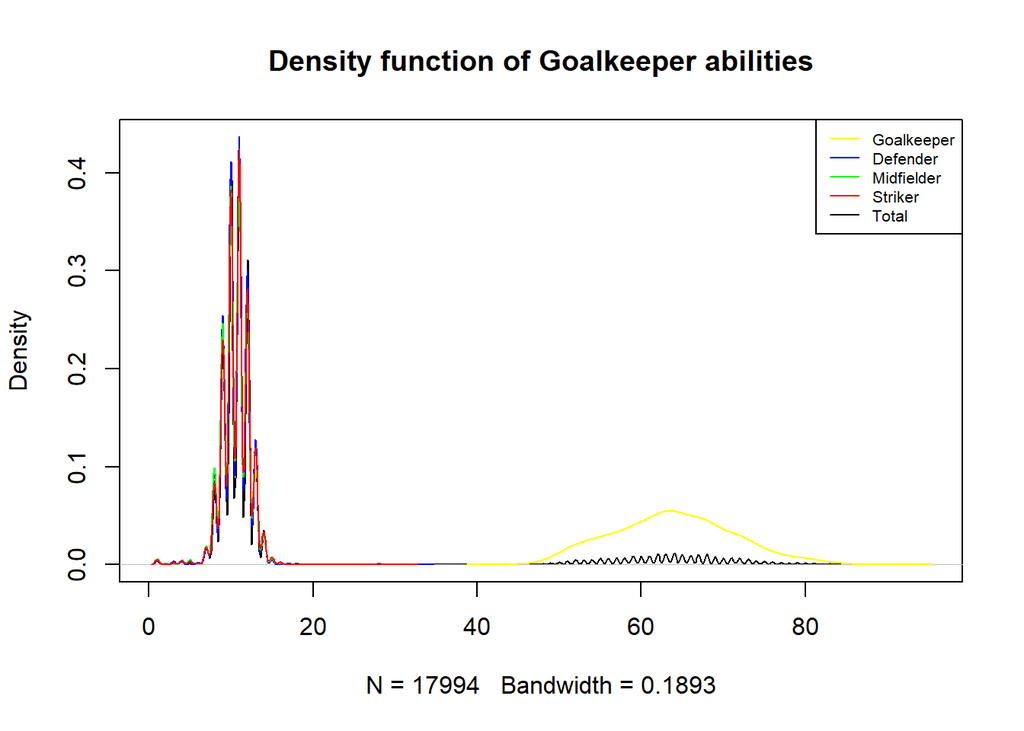

```r
for(i in seq(1,length(fifa.y.qualities), by=1)){
  density.goalkeeper <- density(fifa.x[,i][fifa.y=="Goalkeeper"])
  density.goalkeeper.min.x <- min(density.goalkeeper$x)
  density.goalkeeper.min.y <- min(density.goalkeeper$y)
  density.goalkeeper.max.x <- max(density.goalkeeper$x)
  density.goalkeeper.max.y <- max(density.goalkeeper$y)
  density.defender <- density(fifa.x[,i][fifa.y=="Defender"])
  density.defender.min.x <- min(density.defender$x)
  density.defender.min.y <- min(density.defender$y)
  density.defender.max.x <- max(density.defender$x)
  density.defender.max.y <- max(density.defender$y)
  density.midfielder <- density(fifa.x[,i][fifa.y=="Midfielder"])
  density.midfielder.min.x <- min(density.midfielder$x)
  density.midfielder.min.y <- min(density.midfielder$y)
  density.midfielder.max.x <- max(density.midfielder$x)
  density.midfielder.max.y <- max(density.midfielder$y)
  density.striker <- density(fifa.x[,i][fifa.y=="Striker"])
  density.striker.min.x <- min(density.striker$x)
  density.striker.min.y <- min(density.striker$y)
  density.striker.max.x <- max(density.striker$x)
  density.striker.max.y <- max(density.striker$y)

  density.total <- density(fifa.x[,i])
  density.total.min.x <- min(density.total$x)
  density.total.min.y <- min(density.total$y)
  density.total.max.x <- max(density.total$x)
  density.total.max.y <- max(density.total$y)

  xlim=c(min(density.goalkeeper.min.x, density.defender.min.x, density.midfielder.min.x, density.striker.min.x, density.total.min.x), max(density.goalkeeper.max.x, density.defender.max.x, density.midfielder.max.x, density.striker.max.x, density.total.max.x))

  ylim=c(min(density.goalkeeper.min.y, density.defender.min.y, density.midfielder.min.y, density.striker.min.y, density.total.min.y), max(density.goalkeeper.max.y, density.defender.max.y, density.midfielder.max.y, density.striker.max.y, density.total.max.y))

  plot(density.total, main=paste("Density function of", fifa.y.qualities[i]), col="black", xlim=xlim, ylim=ylim)
  lines(density.goalkeeper, col="yellow")
  lines(density.defender, col="blue")
  lines(density.midfielder, col="green")
  lines(density.striker, col="red")
  legend("topright", legend=c("Goalkeeper", "Defender", "Midfielder", "Striker", "Total"), col=c("yellow", "blue", "green", "red", "black"), lty=1, cex=0.65)
}
```

In addition, in spite of the quantity of observations, which makes really difficult to interpret a parallel coordinates plot (X axis presents the quantitative variables in the same order as at the beginning of the “Dataset preparation” section), it has been included in order to confirm some tendencies extracted from the previous boxplots. For example, if the axis of goalkeeper abilities is observed, there is a clear concentration of goalkeepers in the top; in the passing axis, something similar happens with goalkeepers and midfielders, whereas defenders are in the lowest zone in this ability, as well in shooting and dribbling; or strikers have the dominium in pace.

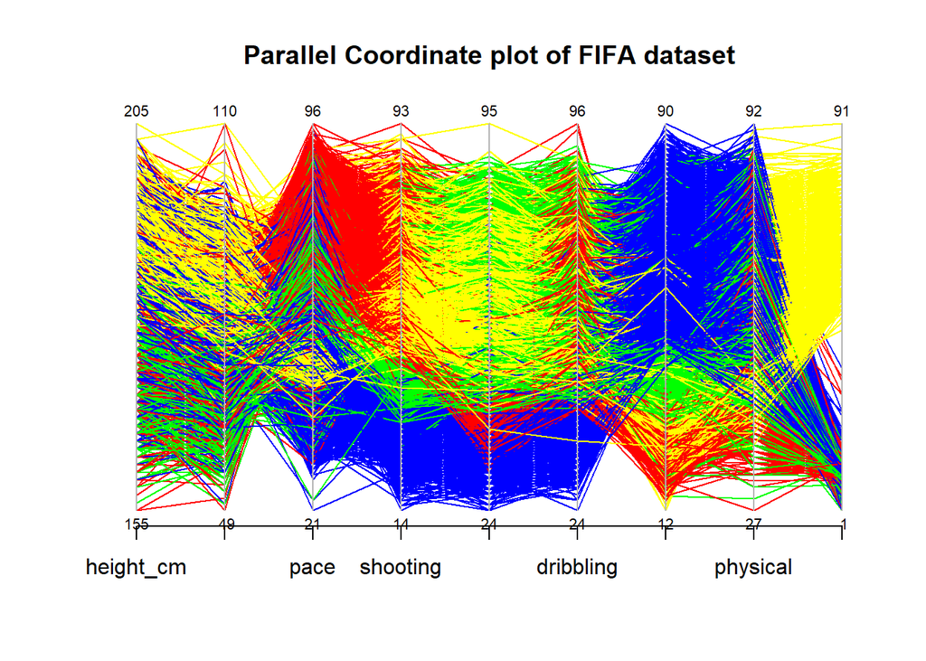

```r
parcoord(fifa.x, col=c("blue", "yellow", "green", "red")[fifa.y], var.label=TRUE, main="Parallel Coordinate plot of FIFA dataset")
```

### 3.3. Principal Component Analysis

The ideal framework would be working with all observation in order to obtain more information. Nevertheless, this means that some of the algorithms would take much time to be developed. Therefore, taking into account that the aim of this project is mainly academic, it has been decided to divided the dataset into two parts but with the same proportion of each studied position. Furthermore, the selected part to work, counts with a train set and a test set with the objective of fitting the model using the train set and then, having an estimate of the model performance with the test set.

Not only the number of observations is a problem when some models are trained, as well as the number of attributes. Nevertheless, it is important to know how to perform a correct dimensions reduction. In this case, the used method is a Principal Component Analysis.

As a result of the PCA, the dataset is transformed into a new one in which the variables are uncorrelated and they are linear combinations of the original ones. In addition, they are ordered by the variance, being the first principal component the corresponging to the highest variance.

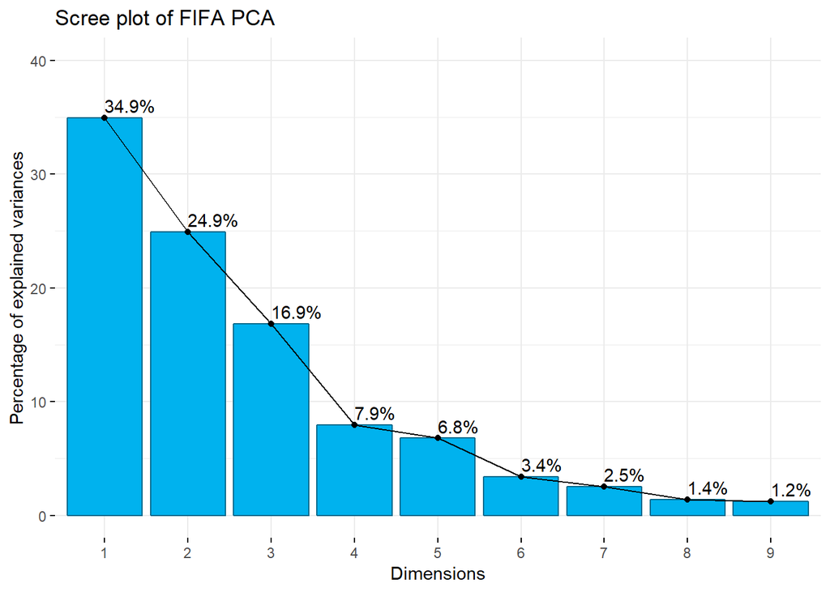

As it can be observed in the previous plot, the first three principal components explain a 76.7% of the variance, what has been considered enough to work only with these transformed variables. In order to visualize the new dataset, some plots have been included.

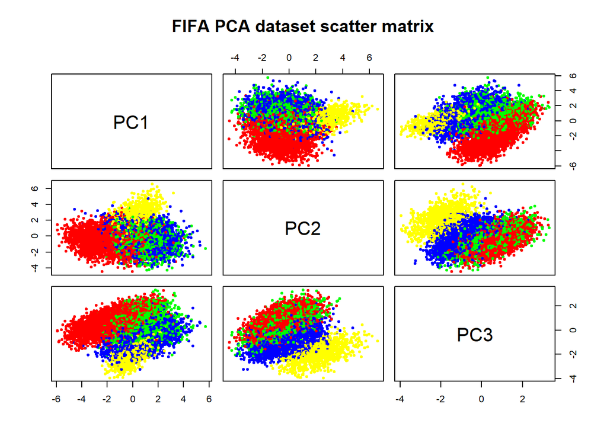

Focusing on data representation after introducing PCA, scatterplots for PC1, PC2 and PC3 have been drawn with the different groups of players in their respective colours used along the report(goalkeepers in yellow, defenders in blue, midfielders in green and strikers in red). In this case, in the first combination between PC1 and PC2, it is observed how strikers are clearly identified, while defenders and midfielders are practically together. On the other hand, PC2 and PC3 seem to help to separate both groups, but it is clear that is complicated to do so. These difficulties are probably caused because there are midfielders with similar characteristics to defenders. In fact, the versatility of midfielders is noticed in PC1 and PC3 scatterplot, in which they are together with defenders. Previous comments are an intuition which makes us think that when some predictions will be performed, the results will be less accurate for this position.

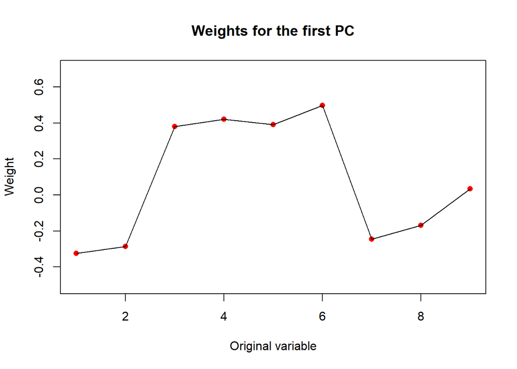

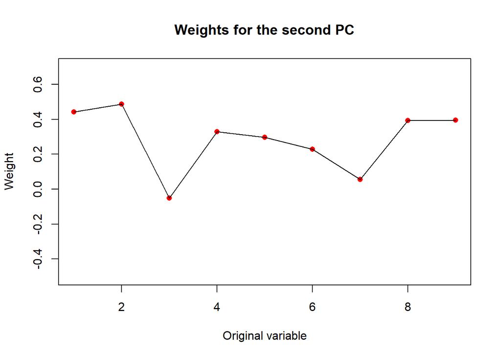

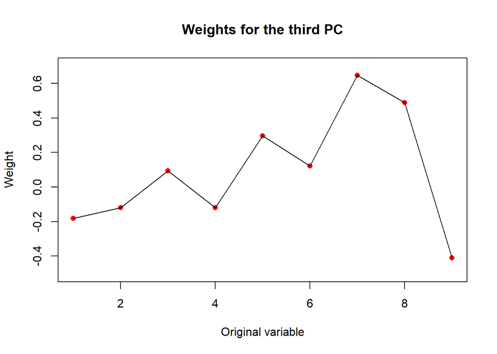

Taking into account only the first three principal components, it seems an evidence that players with acceptable defence and physical conditions, as well high weight and height, are separated from that players whose main abilities are dribbling, passing or shooting. Then, the second principal component gives importance to goalkeepers, who, in general, seems to be heavy and tall people, while they have interesting shooting and physical skills. In addition, the third principal component allows separating the players who are pure defenders from those who could be midfielders with some defence skills. This is due to the fact that it gives a high relevance to physical and defence abilities. Obviously, these weights are related to the previous scatter matrix.

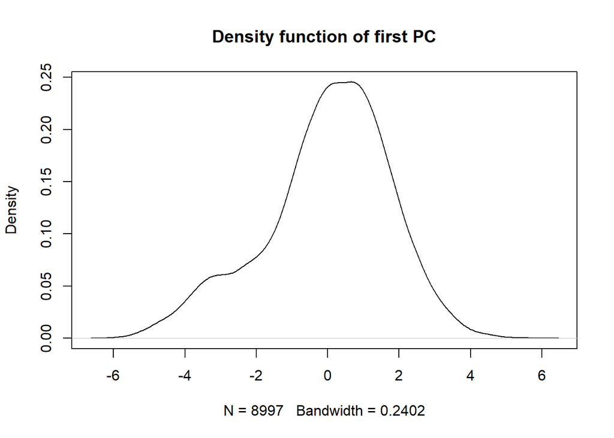

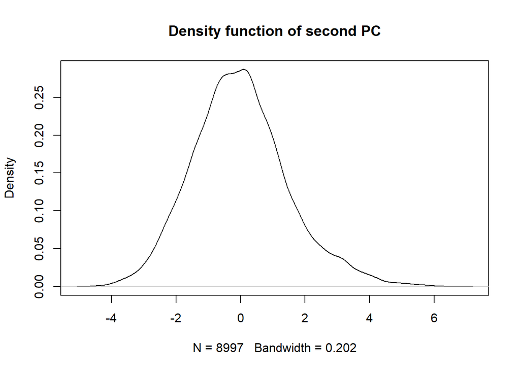

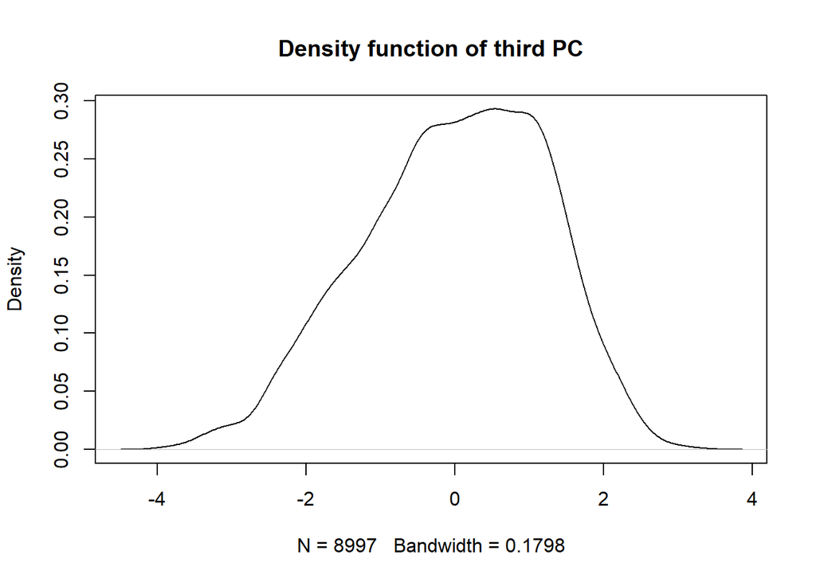

Finally, the density function of each selected principal component has been plotted in order to study the normality of the data. As it can be observed, the functions are not normal. Therefore, in the following sections, for those applied methods which have the assumption of normality, this fact must be taken into account because no appropiated transformation has been found to improve the normality.

```
##
##  Lilliefors (Kolmogorov-Smirnov) normality test
##
## data:  pc1yj
## D = 0.017752, p-value = 5.286e-05
```

```
##
##  Lilliefors (Kolmogorov-Smirnov) normality test
##
## data:  pc2yj
## D = 0.021528, p-value = 1.721e-07
```

```
##
##  Lilliefors (Kolmogorov-Smirnov) normality test
##
## data:  pc3yj
## D = 0.026168, p-value = 2.636e-11
```

Notice that the previous chunk of code try to perform a Yeo-Johnson transformation, but the Lilliefors test rejects the null hypothesis or normality.